# LMM: Solving LM problems

2018-05-15

## Mixed-effects models

- 4.0 Introduction to LMM
- 4.1 Random effects
- 4.2 Solving LM problems using LMM
- 4.3 A showcase of some useful applications
- 4.4 Introduction to GLMM
- 4.5 More complex mixed models

## You will learn in this session

- how to handle temporal and spatial autocorrelation
- how to model heteroskedasticity

## Temporal autocorrelation

## Temporal autocorrelation in discrete (equaly spaced) time steps

## The `AirPassengers` data

```r
AirPassengers
```

```
##      Jan Feb Mar Apr May Jun Jul Aug Sep Oct Nov Dec
## 1949 112 118 132 129 121 135 148 148 136 119 104 118
## 1950 115 126 141 135 125 149 170 170 158 133 114 140
## 1951 145 150 178 163 172 178 199 199 184 162 146 166
## 1952 171 180 193 181 183 218 230 242 209 191 172 194
## 1953 196 196 236 235 229 243 264 272 237 211 180 201
## 1954 204 188 235 227 234 264 302 293 259 229 203 229
## 1955 242 233 267 269 270 315 364 347 312 274 237 278
## 1956 284 277 317 313 318 374 413 405 355 306 271 306
## 1957 315 301 356 348 355 422 465 467 404 347 305 336
## 1958 340 318 362 348 363 435 491 505 404 359 310 337
## 1959 360 342 406 396 420 472 548 559 463 407 362 405
## 1960 417 391 419 461 472 535 622 606 508 461 390 432
```

## The `AirPassengers` data

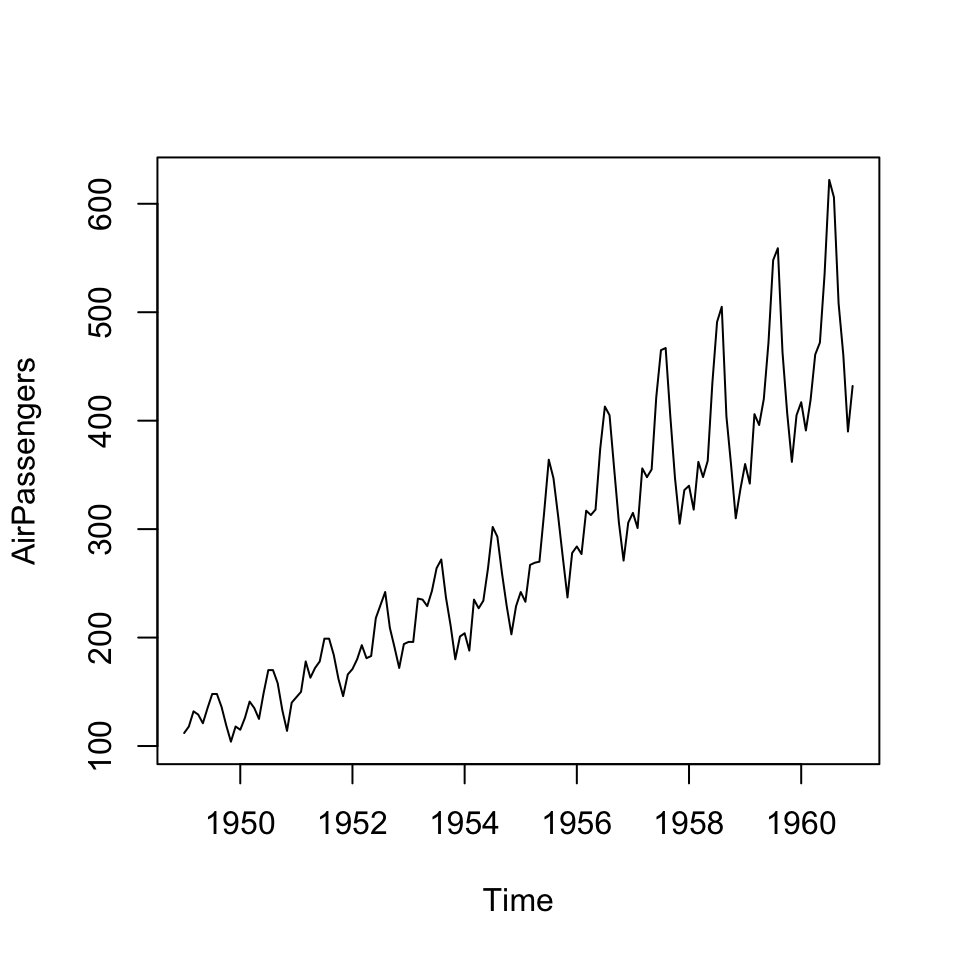

```r
plot(AirPassengers)
```

## Reformating the dataset for the fit

```r
(air <- data.frame(passengers = as.numeric(AirPassengers),
                  year = rep(1949:1960, each = 12),
                  month = factor(rep(1:12, 12))))
```

```
##     passengers year month
## 1          112 1949     1
## 2          118 1949     2
## 3          132 1949     3
## 4          129 1949     4
## 5          121 1949     5
## 6          135 1949     6
## 7          148 1949     7
## 8          148 1949     8
## 9          136 1949     9
## 10         119 1949    10
## 11         104 1949    11
## 12         118 1949    12
## 13         115 1950     1
## 14         126 1950     2
```

[output cut: 130 more lines]

## Looking at the average trend per year

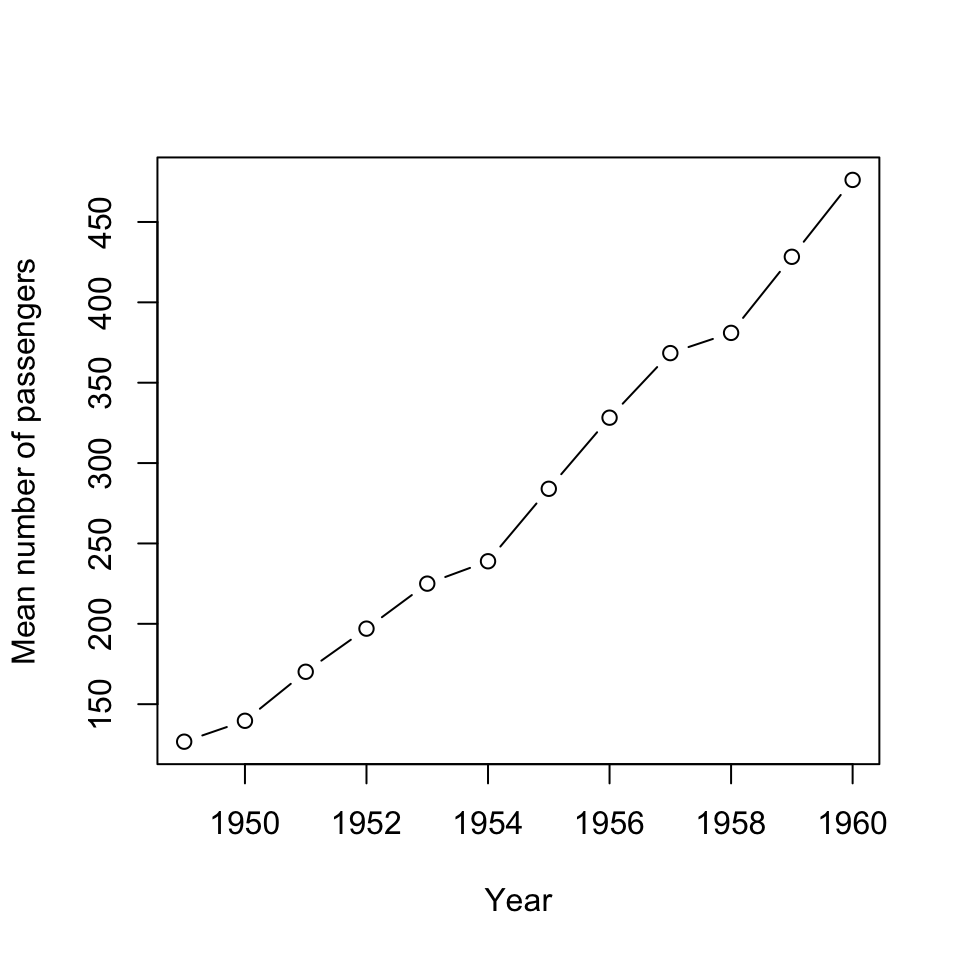

```r
plot(with(air, tapply(passengers, year, mean)) ~ I(1949:1960),
     ylab = "Mean number of passengers", xlab = "Year", type = "b")
```

## Looking at the average trend per month

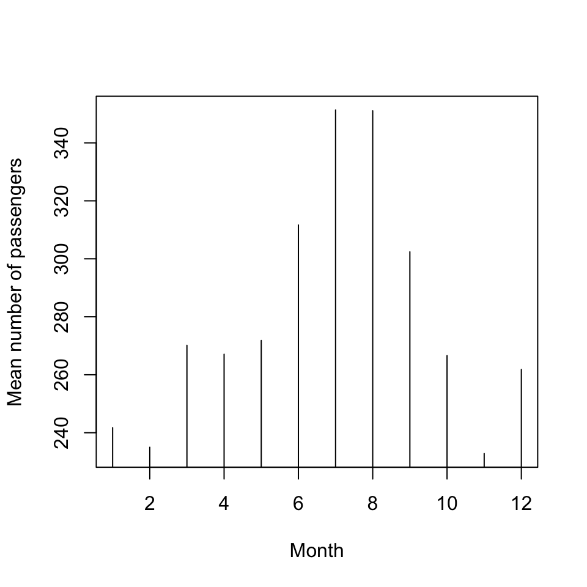

```r
plot(with(air, tapply(passengers, month, mean)) ~ I(1:12),
     ylab = "Mean number of passengers", xlab = "Month", type = "h")
```

## Simple fit

```r
(mod_air <- lm(passengers ~ year * month, data = air))
```

```
##
## Call:
## lm(formula = passengers ~ year * month, data = air)
##
## Coefficients:
##  (Intercept)          year        month2        month3        month4        month5        month6        month7
##   -5.407e+04     2.779e+01     6.356e+03     2.129e+02    -3.118e+03    -7.275e+03    -1.786e+04    -2.994e+04
##       month8        month9       month10       month11       month12   year:month2   year:month3   year:month4
##   -2.936e+04    -1.232e+04    -5.237e+03     3.060e+03    -1.094e+03    -3.255e+00    -9.441e-02     1.608e+00
##  year:month5   year:month6   year:month7   year:month8   year:month9  year:month10  year:month11  year:month12
##    3.738e+00     9.171e+00     1.537e+01     1.508e+01     6.336e+00     2.692e+00    -1.570e+00     5.699e-01
```

## The problem

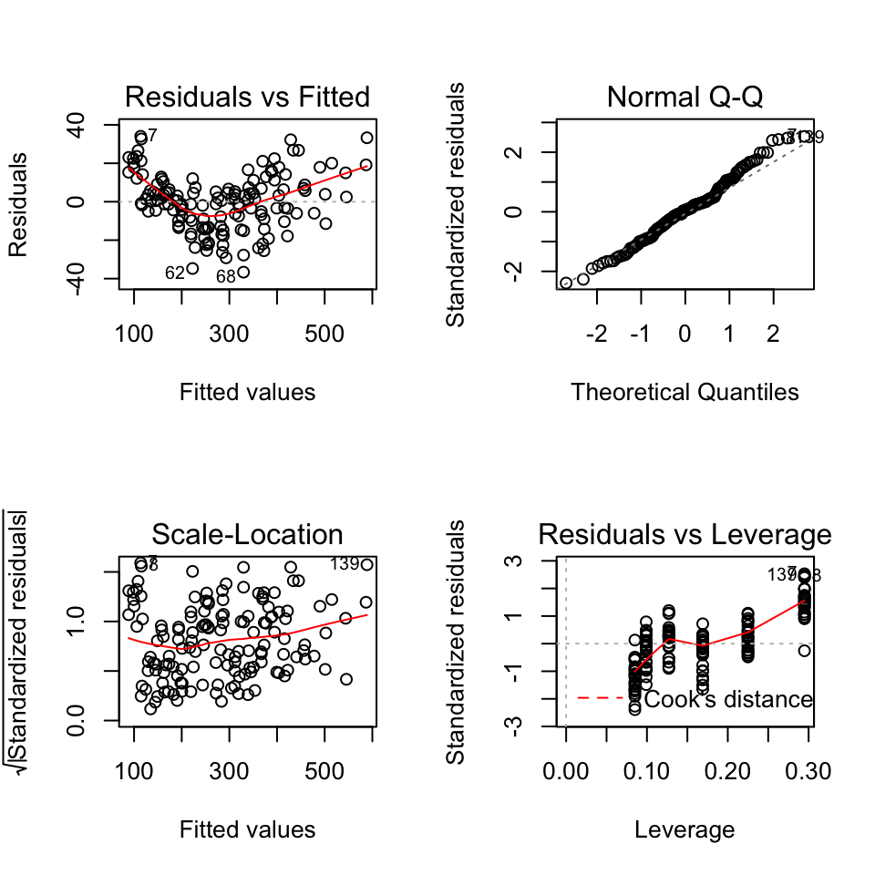

```r
par(mfrow = c(2, 2))
plot(mod_air)
```

## The problem

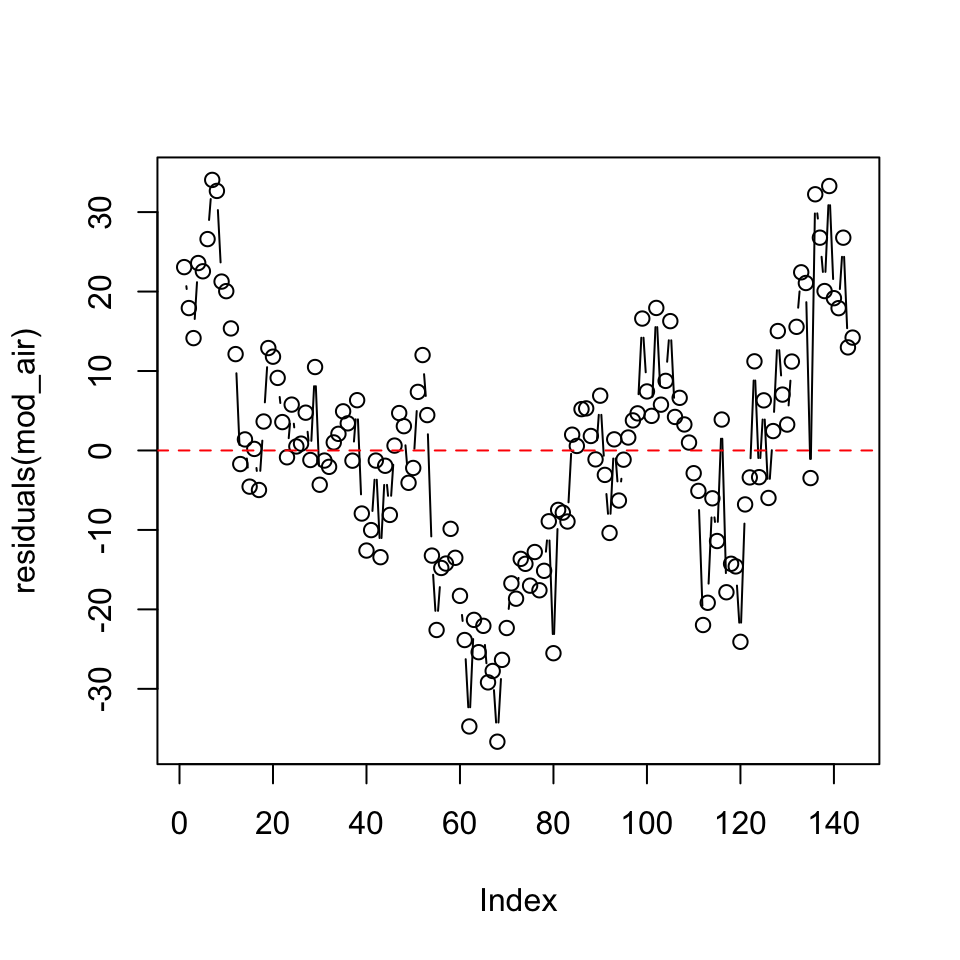

```r
plot(residuals(mod_air), type = "b")
abline(h = 0, lty = 2, col = "red")
```

## The problem

```r
lmtest::dwtest(mod_air)
```

```
##
##  Durbin-Watson test
##
## data:  mod_air
## DW = 0.35903, p-value < 2.2e-16
## alternative hypothesis: true autocorrelation is greater than 0
```

## The problem

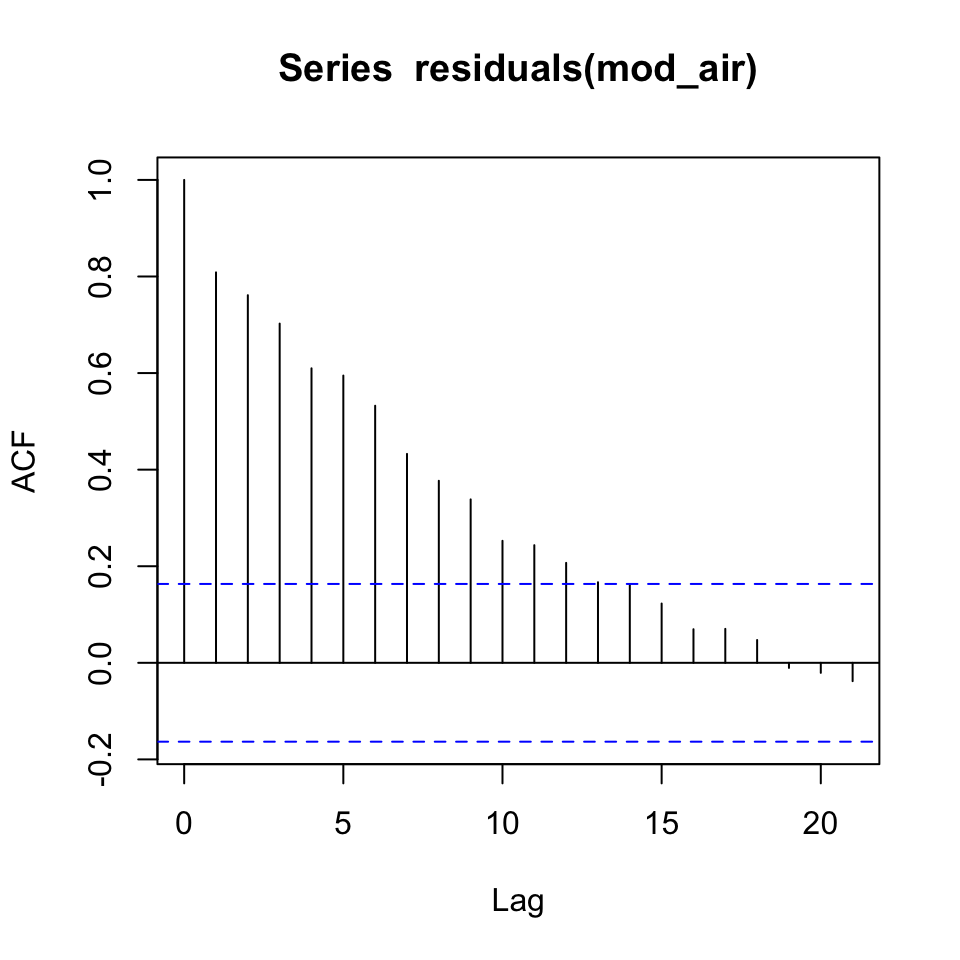

```r
acf(residuals(mod_air))
```

## Solution

```r
air$year_bis <- air$year - 1949
air$time <- 1:nrow(air)
library(spaMM)
(mod_air_spaMM1 <- fitme(passengers ~ month * year_bis + AR1(1|time), data = air))
```

```
## formula: passengers ~ month * year_bis + AR1(1 | time)
## ML: Estimation of lambda, phi and corrPars by ML.
##     Estimation of fixed effects by ML.
## Family: gaussian ( link = identity )
##  ------------ Fixed effects (beta) ------------
##                  Estimate Cond. SE t-value
## (Intercept)       90.6876  12.5150   7.246
## month2            11.9344   4.6177   2.584
## month3            30.5025   5.1075   5.972
## month4            18.8471   5.4689   3.446
## month5            12.6879   5.7265   2.216
## month6            23.4496   5.8937   3.979
## month7            29.8265   5.9776   4.990
## month8            32.0510   5.9807   5.359
## month9            32.3172   5.9020   5.476
## month10           17.3964   5.7362   3.033
## month11            7.9826   5.4733   1.458
## month12           26.1291   5.0953   5.128
## year_bis          28.3475   1.7153  16.526
## month2:year_bis   -3.4034   0.7105  -4.790
## month3:year_bis   -0.3899   0.7846  -0.497
## month4:year_bis    1.1662   0.8384   1.391
## month5:year_bis    3.1491   0.8760   3.595
## month6:year_bis    8.4361   0.8996   9.378
## month7:year_bis   14.4920   0.9103  15.920
## month8:year_bis   14.0472   0.9086  15.460
## month9:year_bis    5.1573   0.8944   5.766
## month10:year_bis   1.3640   0.8670   1.573
## month11:year_bis  -3.0499   0.8249  -3.697
## month12:year_bis  -1.0637   0.7652  -1.390
##  --------------- Random effects ---------------
## Family: gaussian ( link = identity )
##                    --- Correlation parameters:
##   1.ARphi
## 0.9543957
##            --- Variance parameters ('lambda'):
## lambda = var(u) for u ~ Gaussian;
##    time  :  224.7
##              --- Coefficients for log(lambda):
##  Group        Term Estimate Cond.SE
##   time (Intercept)    5.415  0.1844
## # of obs: 144; # of groups: time, 144
##  ------------- Residual variance  -------------
## Coefficients for log(phi) ~ 1 :
##             Estimate Cond. SE
## (Intercept)    3.276   0.1533
## Estimate of phi=residual var:  26.47
##  ------------- Likelihood values  -------------
##                         logLik
## p_v(h) (marginal L): -499.8833
```

## Solution

```r
 mod_air_spaMM1$corrPars[[1]]
```

```
## $ARphi
## [1] 0.9543957
```

## Fitted values

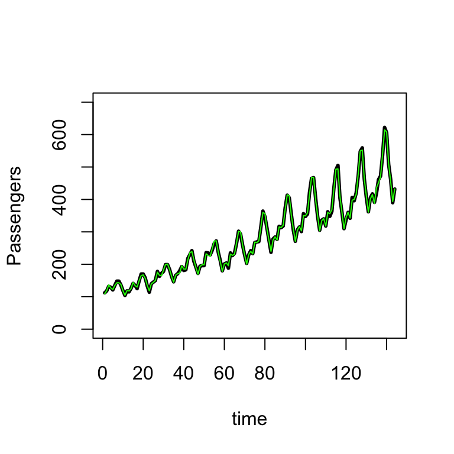

```r
pred_spaMM <- predict(mod_air_spaMM1)
plot(passengers ~ time, data = air, type = "l", lwd = 3, ylim = c(0, 700), ylab = "Passengers")
points(pred_spaMM ~ air$time, type = "l", col = "green")
```

Note: never extrapolate using such model! The perfect fit is not unusual.

## Testing the effect of years

```r
mod_air_spaMM_no_year <- fitme(passengers ~ month + AR1(1|time), data = air)
```

[output not shown]

```r
anova(mod_air_spaMM1, mod_air_spaMM_no_year)
```

```
##      chi2_LR df p_value
## p_v 637.7874 12       0
```

## Temporal autocorrelation in continuous time

## The `nlme::BodyWeight` dataset

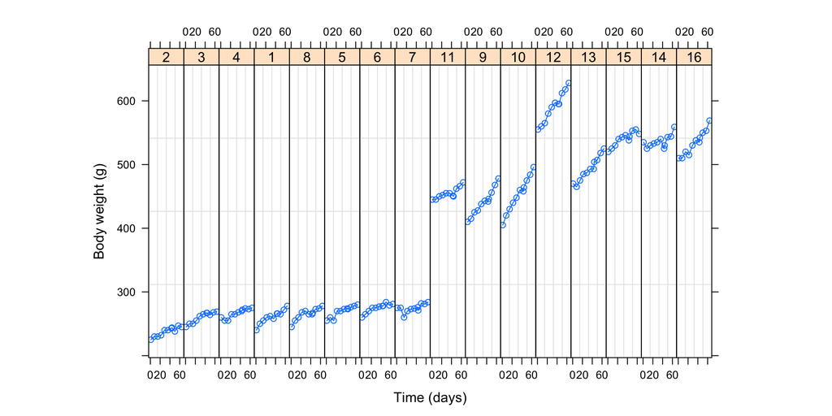

```r
data("BodyWeight", package = "nlme")
plot(BodyWeight)
```

## The `nlme::BodyWeight` dataset

```r
body <- as.data.frame(BodyWeight)
body$Rat <- factor(body$Rat, levels = 1:16, order = FALSE)
str(body)
```

```
## 'data.frame':    176 obs. of  4 variables:
##  $ weight: num  240 250 255 260 262 258 266 266 265 272 ...
##  $ Time  : num  1 8 15 22 29 36 43 44 50 57 ...
##  $ Rat   : Factor w/ 16 levels "1","2","3","4",..: 1 1 1 1 1 1 1 1 1 1 ...
##  $ Diet  : Factor w/ 3 levels "1","2","3": 1 1 1 1 1 1 1 1 1 1 ...
```

```r
unique(body$Time)
```

```
##  [1]  1  8 15 22 29 36 43 44 50 57 64
```

## Fitting with the exponential correlation function

```r
(mod_rat_spaMM1 <- fitme(weight ~ Diet * Time + (Time|Rat) + Matern(1|Time),
                         fixed = list(nu = 0.5),
                         data = body, method = "REML"))
```

```
## formula: weight ~ Diet * Time + (Time | Rat) + Matern(1 | Time)
## REML: Estimation of lambda, phi, corrPars and ranCoefs by REML.
##       Estimation of fixed effects by ML.
## Family: gaussian ( link = identity )
##  ------------ Fixed effects (beta) ------------
##             Estimate Cond. SE t-value
## (Intercept) 251.6434 13.15459  19.130
## Diet2       200.6655 22.67951   8.848
## Diet3       252.0717 22.67951  11.115
## Time          0.3682  0.09668   3.808
## Diet2:Time    0.6058  0.15786   3.838
## Diet3:Time    0.2983  0.15786   1.890
##  --------------- Random effects ---------------
## Family: gaussian ( link = identity )
##                    --- Correlation parameters:
##      2.nu     2.rho
## 0.5000000 0.1695024
##          --- Random-coefficients Cov matrices:
##  Group        Term   Var.   Corr.
##    Rat (Intercept)   1366
##    Rat        Time 0.0624 -0.1507
##            --- Variance parameters ('lambda'):
## lambda = var(u) for u ~ Gaussian;
##    Time  :  2.844
##              --- Coefficients for log(lambda):
##  Group        Term Estimate Cond.SE
##   Time (Intercept)    1.045  0.5868
## # of obs: 176; # of groups: Rat, 32; Time, 11
##  ------------- Residual variance  -------------
## Coefficients for log(phi) ~ 1 :
##             Estimate Cond. SE
## (Intercept)    2.826     0.12
## Estimate of phi=residual var:  16.88
##  ------------- Likelihood values  -------------
##                         logLik
## p_v(h) (marginal L): -577.0637
##   p_beta,v(h) (ReL): -569.5571
```

## Fitting with the `Matern()` correlation function

```r
(mod_rat_spaMM2 <- fitme(weight ~ Diet * Time + (Time|Rat) + Matern(1|Time),
                         data = body, method = "REML"))
```

```
## formula: weight ~ Diet * Time + (Time | Rat) + Matern(1 | Time)
## REML: Estimation of lambda, phi, corrPars and ranCoefs by REML.
##       Estimation of fixed effects by ML.
## Family: gaussian ( link = identity )
##  ------------ Fixed effects (beta) ------------
##             Estimate Cond. SE t-value
## (Intercept) 251.6614 13.14654  19.143
## Diet2       200.6655 22.67952   8.848
## Diet3       252.0717 22.67952  11.115
## Time          0.3681  0.09606   3.832
## Diet2:Time    0.6058  0.15786   3.838
## Diet3:Time    0.2983  0.15786   1.890
##  --------------- Random effects ---------------
## Family: gaussian ( link = identity )
##                    --- Correlation parameters:
##      2.nu     2.rho
## 16.666667  1.259111
##          --- Random-coefficients Cov matrices:
##  Group        Term    Var.   Corr.
##    Rat (Intercept)    1366
##    Rat        Time 0.06239 -0.1507
##            --- Variance parameters ('lambda'):
## lambda = var(u) for u ~ Gaussian;
##    Time  :  2.633
##              --- Coefficients for log(lambda):
##  Group        Term Estimate Cond.SE
##   Time (Intercept)    0.968  0.6065
## # of obs: 176; # of groups: Rat, 32; Time, 11
##  ------------- Residual variance  -------------
## Coefficients for log(phi) ~ 1 :
##             Estimate Cond. SE
## (Intercept)    2.828   0.1198
## Estimate of phi=residual var:  16.91
##  ------------- Likelihood values  -------------
##                         logLik
## p_v(h) (marginal L): -576.8759
##   p_beta,v(h) (ReL): -569.3814
```

## Plotting the autocorrelation functions

```r
time_for_pred <- seq(0, 30, length.out = 100)
pred_corr1 <- MaternCorr(time_for_pred,
                         rho = mod_rat_spaMM1$corrPars[[1]]$rho,
                         nu = mod_rat_spaMM1$corrPars[[1]]$nu)
pred_corr2 <- MaternCorr(time_for_pred,
                         rho = mod_rat_spaMM2$corrPars[[1]]$rho,
                         nu = mod_rat_spaMM2$corrPars[[1]]$nu)
```

## Plotting the autocorrelation functions

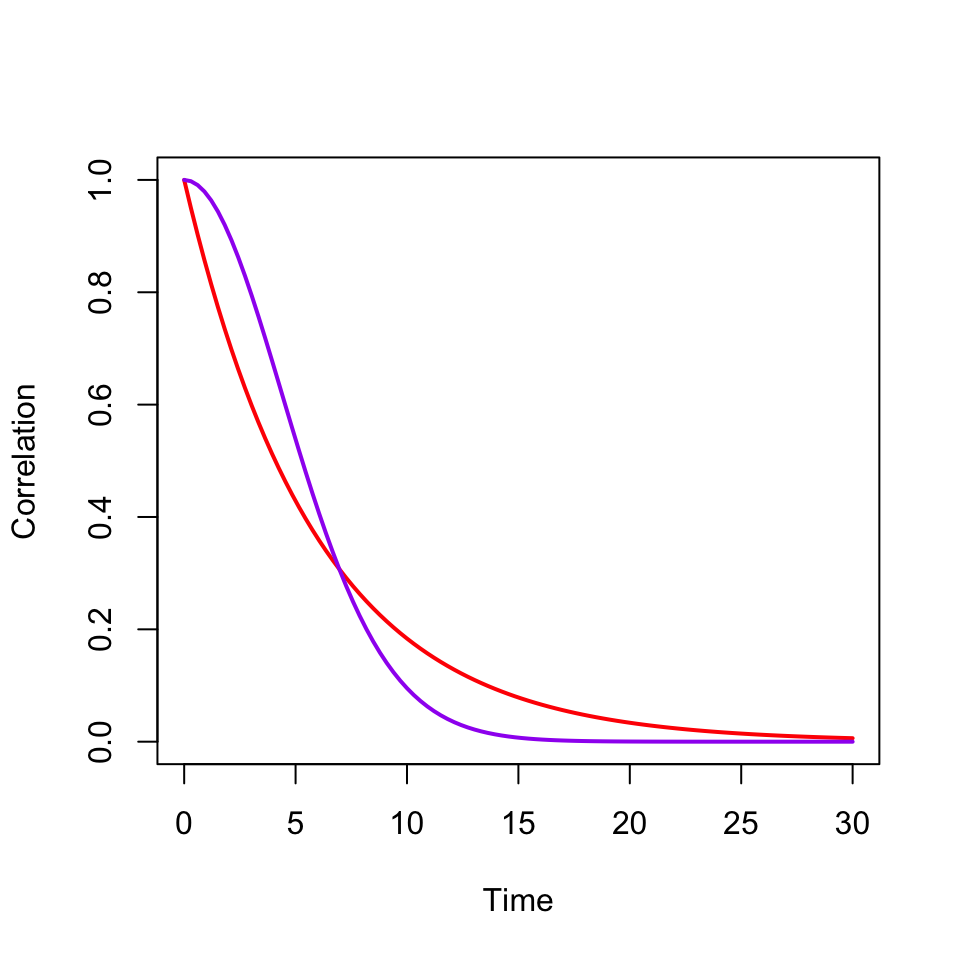

```r
plot(pred_corr1 ~ time_for_pred, type = "l", lwd = 2, col = "red", ylim = c(0, 1), xlab="Time", ylab="Correlation")
points(pred_corr2 ~ time_for_pred, type = "l", lwd = 2, col = "purple", ylim = c(0, 1))
```

## Model comparison

```r
print(AIC(mod_rat_spaMM1))
```

```
##        marginal AIC:     conditional AIC:      dispersion AIC:        effective df:
##            1174.1275            1035.8757            1147.1142             139.0042
```

```r
print(AIC(mod_rat_spaMM2))
```

```
##        marginal AIC:     conditional AIC:      dispersion AIC:        effective df:
##            1173.7517            1035.7574            1146.7629             139.3773
```

Note: the model do not look really different in their ability to fit the data.

## AR1

```r
(mod_rat_spaMM_AR1 <- fitme(weight ~ Diet * Time + (Time|Rat) + AR1(1|Time),
                            data = body, method = "REML"))
```

```
## formula: weight ~ Diet * Time + (Time | Rat) + AR1(1 | Time)
## REML: Estimation of lambda, phi, corrPars and ranCoefs by REML.
##       Estimation of fixed effects by ML.
## Family: gaussian ( link = identity )
##  ------------ Fixed effects (beta) ------------
##             Estimate Cond. SE t-value
## (Intercept) 251.6434 13.15459  19.130
## Diet2       200.6655 22.67950   8.848
## Diet3       252.0717 22.67950  11.115
## Time          0.3682  0.09668   3.808
## Diet2:Time    0.6058  0.15786   3.838
## Diet3:Time    0.2983  0.15786   1.890
##  --------------- Random effects ---------------
## Family: gaussian ( link = identity )
##                    --- Correlation parameters:
##   2.ARphi
## 0.8440847
##          --- Random-coefficients Cov matrices:
##  Group        Term   Var.   Corr.
##    Rat (Intercept)   1366
##    Rat        Time 0.0624 -0.1507
##            --- Variance parameters ('lambda'):
## lambda = var(u) for u ~ Gaussian;
##    Time  :  2.844
##              --- Coefficients for log(lambda):
##  Group        Term Estimate Cond.SE
##   Time (Intercept)    1.045  0.5868
## # of obs: 176; # of groups: Rat, 32; Time, 11
##  ------------- Residual variance  -------------
## Coefficients for log(phi) ~ 1 :
##             Estimate Cond. SE
## (Intercept)    2.826     0.12
## Estimate of phi=residual var:  16.88
##  ------------- Likelihood values  -------------
##                         logLik
## p_v(h) (marginal L): -577.0637
##   p_beta,v(h) (ReL): -569.5571
```

## AR1 vs Matern

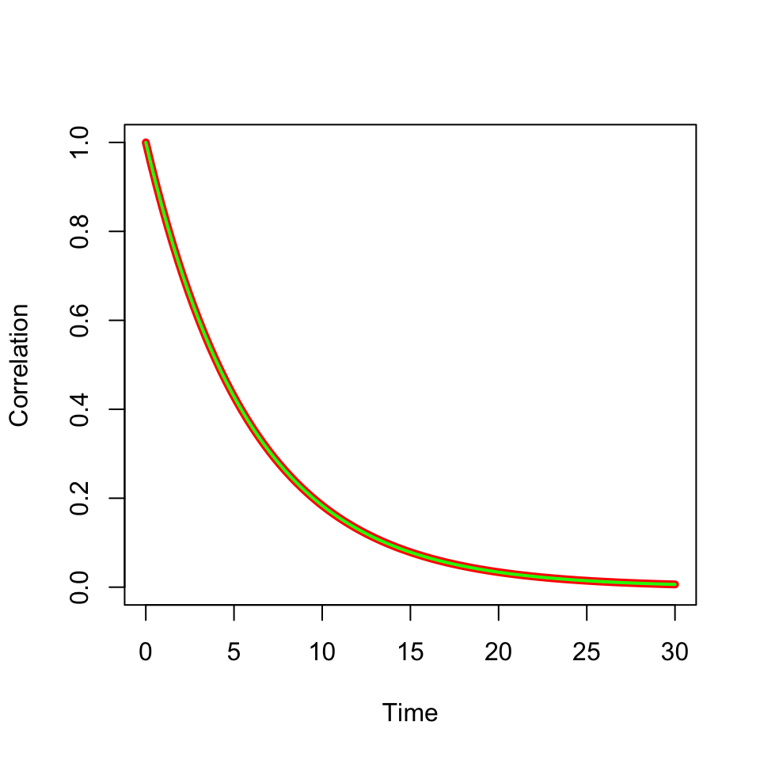

```r
pred_corr3 <- mod_rat_spaMM_AR1$corrPars[[1]]$ARphi^time_for_pred
plot(pred_corr1 ~ time_for_pred, type = "l", lwd = 5, col = "red", ylim = c(0, 1), xlab="Time", ylab="Correlation")
points(pred_corr3 ~ time_for_pred, type = "l", lwd = 2, col = "green", ylim = c(0, 1))
```

## AR1 vs Matern

```r
logLik(mod_rat_spaMM1)[[1]] ## Matern nu = 0.5
```

```
## [1] -569.5571
```

```r
logLik(mod_rat_spaMM_AR1)[[1]] ## AR1
```

```
## [1] -569.5571
```

```r
round(fixef(mod_rat_spaMM1) - fixef(mod_rat_spaMM_AR1), 3)
```

```
## (Intercept)       Diet2       Diet3        Time  Diet2:Time  Diet3:Time
##           0           0           0           0           0           0
```

Note 1: AR1 and Matern (with nu = 0.5) are equivalent (if time is discrete)!

Note 2: AR1 cannot work if time is not discrete.

## Model comparison

```r
mod_rat_spaMM_noAR <- fitme(weight ~ Diet * Time + (Time|Rat), data = body,
                            method = "REML")
```

```r
print(AIC(mod_rat_spaMM1))
```

```
##        marginal AIC:     conditional AIC:      dispersion AIC:        effective df:
##            1174.1275            1035.8757            1147.1142             139.0042
```

```r
print(AIC(mod_rat_spaMM_noAR))
```

```
##        marginal AIC:     conditional AIC:      dispersion AIC:        effective df:
##            1180.5026            1057.5118            1153.7197             144.9506
```

Note: the model accounting for the autocorrelation fits the data best!

## Testing the overall effect of diet

### `spaMM`

```r
mod_rat_spaMM3ML <- fitme(weight ~ Diet * Time + (Time|Rat) + AR1(1|Time),
                          data = body, method = "ML")
mod_rat_no_diet <- fitme(weight ~ 1 + Time + (Time|Rat) + AR1(1|Time),
                          data = body, method = "ML")
anova(mod_rat_spaMM3ML, mod_rat_no_diet)
```

```
##      chi2_LR df      p_value
## p_v 47.77998  4 1.048901e-09
```

## More complex autocorrelation functions

There are more complex autocorrelation functions out there.

`spaMM`:

```r
(mod_rat_Matern_nugget <- fitme(weight ~ Diet * Time + (Time|Rat) + Matern(1|Time), data = body,
                                init = list(Nugget = 0.1)))  ## here estimated at zero but does not have to be!
```

```
## formula: weight ~ Diet * Time + (Time | Rat) + Matern(1 | Time)
## ML: Estimation of lambda, phi, corrPars and ranCoefs by ML.
##     Estimation of fixed effects by ML.
## Family: gaussian ( link = identity )
##  ------------ Fixed effects (beta) ------------
##             Estimate Cond. SE t-value
## (Intercept) 251.6621 11.86108  21.217
## Diet2       200.6655 20.45284   9.811
## Diet3       252.0717 20.45284  12.325
## Time          0.3678  0.08757   4.200
## Diet2:Time    0.6058  0.14317   4.232
## Diet3:Time    0.2983  0.14317   2.084
##  --------------- Random effects ---------------
## Family: gaussian ( link = identity )
##                    --- Correlation parameters:
##  2.Nugget      2.nu     2.rho
##  0.000000 16.666667  1.318249
##          --- Random-coefficients Cov matrices:
##  Group        Term   Var.   Corr.
##    Rat (Intercept)   1109
##    Rat        Time 0.0506 -0.1503
##            --- Variance parameters ('lambda'):
## lambda = var(u) for u ~ Gaussian;
##    Time  :  2.459
##              --- Coefficients for log(lambda):
##  Group        Term Estimate Cond.SE
##   Time (Intercept)   0.8999  0.5979
## # of obs: 176; # of groups: Rat, 32; Time, 11
##  ------------- Residual variance  -------------
## Coefficients for log(phi) ~ 1 :
##             Estimate Cond. SE
## (Intercept)    2.828   0.1196
## Estimate of phi=residual var:  16.91
##  ------------- Likelihood values  -------------
##                         logLik
## p_v(h) (marginal L): -576.5687
```

## More complex autocorrelation functions

There are more complex autocorrelation functions out there.

`nlme`:

```r
library(nlme)
mod_rat1 <- lme(weight ~ Diet * Time, random = ~ Time|Rat, data = body)
mod_rat_AR1 <- update(mod_rat1, corr = corAR1(form = ~ Time))
mod_rat_corExp <- update(mod_rat1, corr = corExp(form = ~ Time, nugget = FALSE))
mod_rat_corExp_Nugget <- update(mod_rat1, corr = corExp(form = ~ Time, nugget = TRUE))
mod_rat_corRatio <- update(mod_rat1, corr = corRatio(form = ~ Time))
mod_rat_corSpher <- update(mod_rat1, corr = corSpher(form = ~ Time))
mod_rat_corLin <- update(mod_rat1, corr = corLin(form = ~ Time))
mod_rat_corGaus <- update(mod_rat1, corr = corGaus(form = ~ Time))
c(AIC(mod_rat1)[[1]], AIC(mod_rat_AR1)[[1]], AIC(mod_rat_corExp)[[1]],  AIC(mod_rat_corExp_Nugget)[[1]],
  AIC(mod_rat_corRatio)[[1]], AIC(mod_rat_corSpher)[[1]], AIC(mod_rat_corLin)[[1]], AIC(mod_rat_corGaus)[[1]])
```

```
## [1] 1171.720 1154.059 1154.059 1151.768 1155.749 1157.233 1157.233 1157.233
```

Note: do not compare AIC between `spaMM` and `nlme`, as the latter seems not to account for a fixed term in the computation of the likelihood!

## Spatial autocorrelation

## Maximum normalised-difference vegetation index in north Cameroon

```r
data("Loaloa")
ndvi <- Loaloa[, c("maxNDVI", "latitude", "longitude")]
head(ndvi)
```

```
##    maxNDVI latitude longitude
## X1    0.69 5.736750  8.041860
## X2    0.74 5.680280  8.004330
## X3    0.79 5.347222  8.905556
## X4    0.67 5.917420  8.100720
## X5    0.85 5.104540  8.182510
## X6    0.80 5.355556  8.929167
```

## Visualising the data

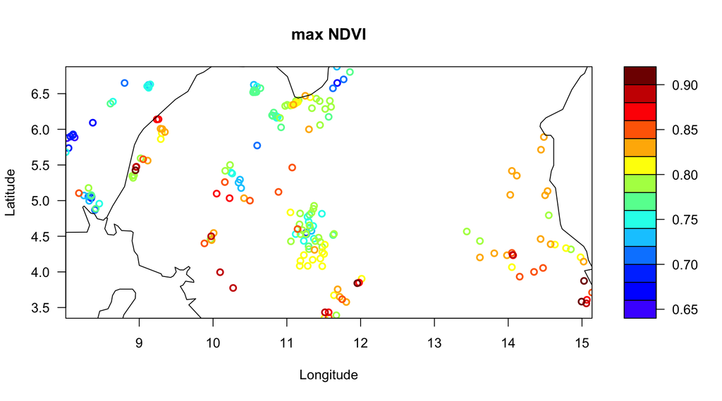

```r
library(maps)
spaMMplot2D(x = ndvi$longitude, y = ndvi$latitude, z = ndvi$maxNDVI, add.map = TRUE,
            xlab = "Longitude", ylab = "Latitude", plot.title = title(main = "max NDVI"))
```

## Visualising the data

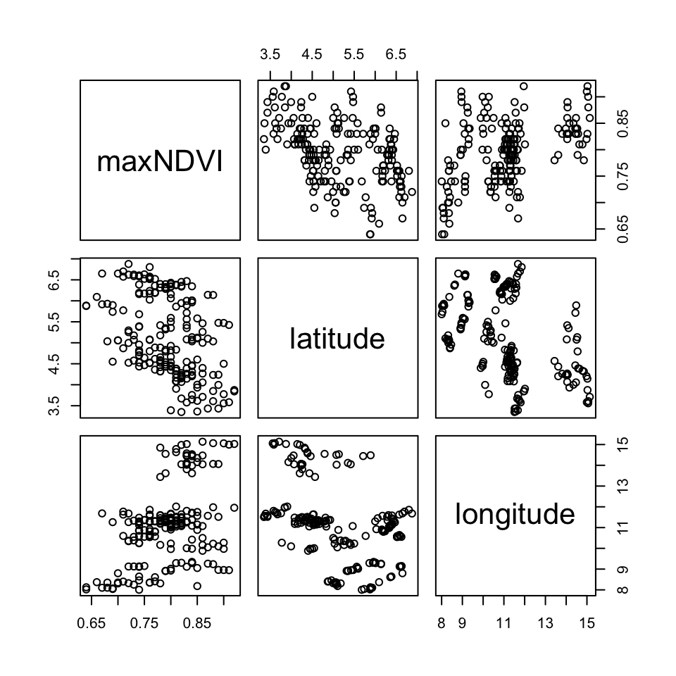

```r
pairs(ndvi)
```

## Fitting the model

```r
(mod_ndvi1 <- fitme(maxNDVI ~ 1 + Matern(1|longitude + latitude), data = ndvi, method = "REML"))
```

```
## formula: maxNDVI ~ 1 + Matern(1 | longitude + latitude)
## REML: Estimation of lambda, phi and corrPars by REML.
##       Estimation of fixed effects by ML.
## Family: gaussian ( link = identity )
##  ------------ Fixed effects (beta) ------------
##             Estimate Cond. SE t-value
## (Intercept)   0.8006  0.02391   33.48
##  --------------- Random effects ---------------
## Family: gaussian ( link = identity )
##                    --- Correlation parameters:
##      1.nu     1.rho
## 0.4066726 0.9345780
##            --- Variance parameters ('lambda'):
## lambda = var(u) for u ~ Gaussian;
##    longitude.  :  0.004322
##              --- Coefficients for log(lambda):
##       Group        Term Estimate Cond.SE
##  longitude. (Intercept)   -5.444  0.1229
## # of obs: 197; # of groups: longitude., 197
##  ------------- Residual variance  -------------
## Coefficients for log(phi) ~ 1 :
##             Estimate Cond. SE
## (Intercept)   -8.219   0.1775
## Estimate of phi=residual var:  0.0002696
##  ------------- Likelihood values  -------------
##                        logLik
## p_v(h) (marginal L): 378.1405
##   p_beta,v(h) (ReL): 375.3261
```

## Predictions

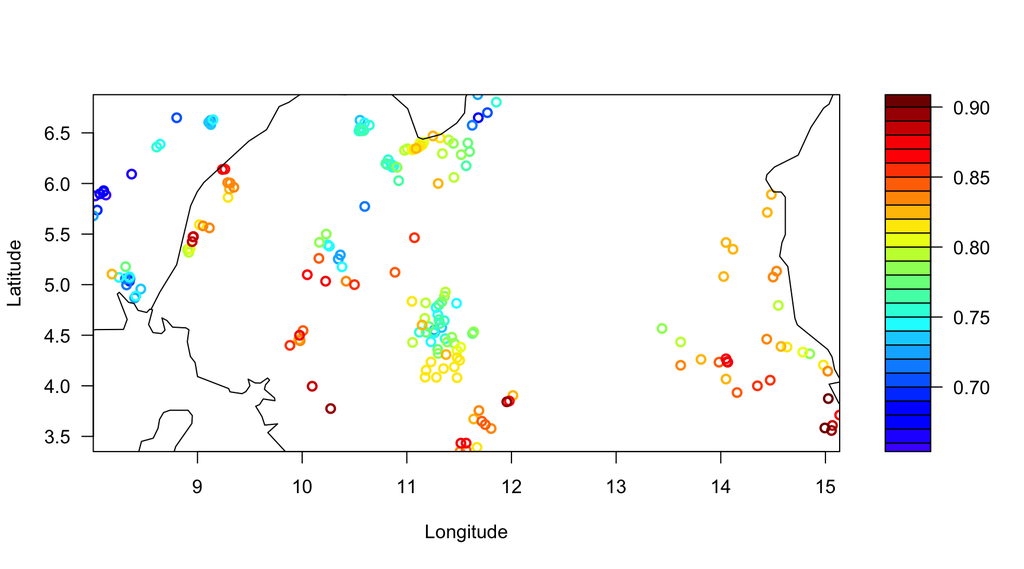

```r
mapMM(mod_ndvi1, add.map = TRUE, plot.title = title(xlab = "Longitude", ylab = "Latitude"))
```

## Predictions

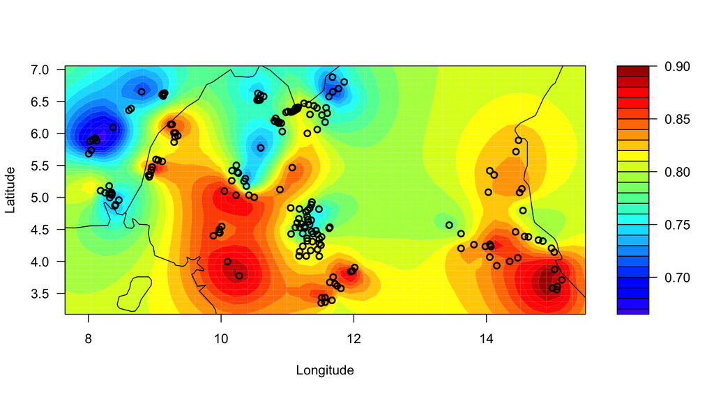

```r
filled.mapMM(mod_ndvi1, add.map = TRUE, plot.title = title(xlab = "Longitude", ylab = "Latitude"))
```

## Prediction uncertainty

```r
x.for.pred <- seq(min(ndvi$longitude), max(ndvi$longitude), length.out = 100)
y.for.pred <- seq(min(ndvi$latitude), max(ndvi$latitude), length.out = 50)
data.for.pred <- expand.grid(longitude = x.for.pred, latitude = y.for.pred)
gridpred <- predict(mod_ndvi1, newdata = data.for.pred, variances = list(predVar = TRUE))
data.for.pred$predVar <- attr(gridpred, "predVar")
m <- matrix(data.for.pred$predVar, ncol = length(y.for.pred))
```

## Prediction uncertainty

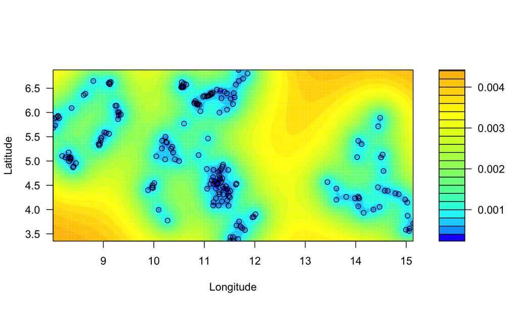

```r
spaMM.filled.contour(x = x.for.pred, y = y.for.pred, z = m, plot.axes = {
  points(ndvi[, c("longitude", "latitude")]); axis(1); axis(2)}, col = spaMM.colors(redshift = 3),
  plot.title = title(xlab = "Longitude", ylab = "Latitude"))
```

## Heteroscedasticity

## Heteroscedasticity

We used random effects to model variance components from random variables.

We can thus use the same kind of tools to also model the variance components of the errors.

Do not mix-up random variance components from residual ones: remember that in the error, all covariance terms are null (by definition).

## Let's revisit the rats

```r
mod_rat_spaMM <- fitme(weight ~ Diet * Time + (Time|Rat) + AR1(1|Time), data = body,
                            method = "REML")
```

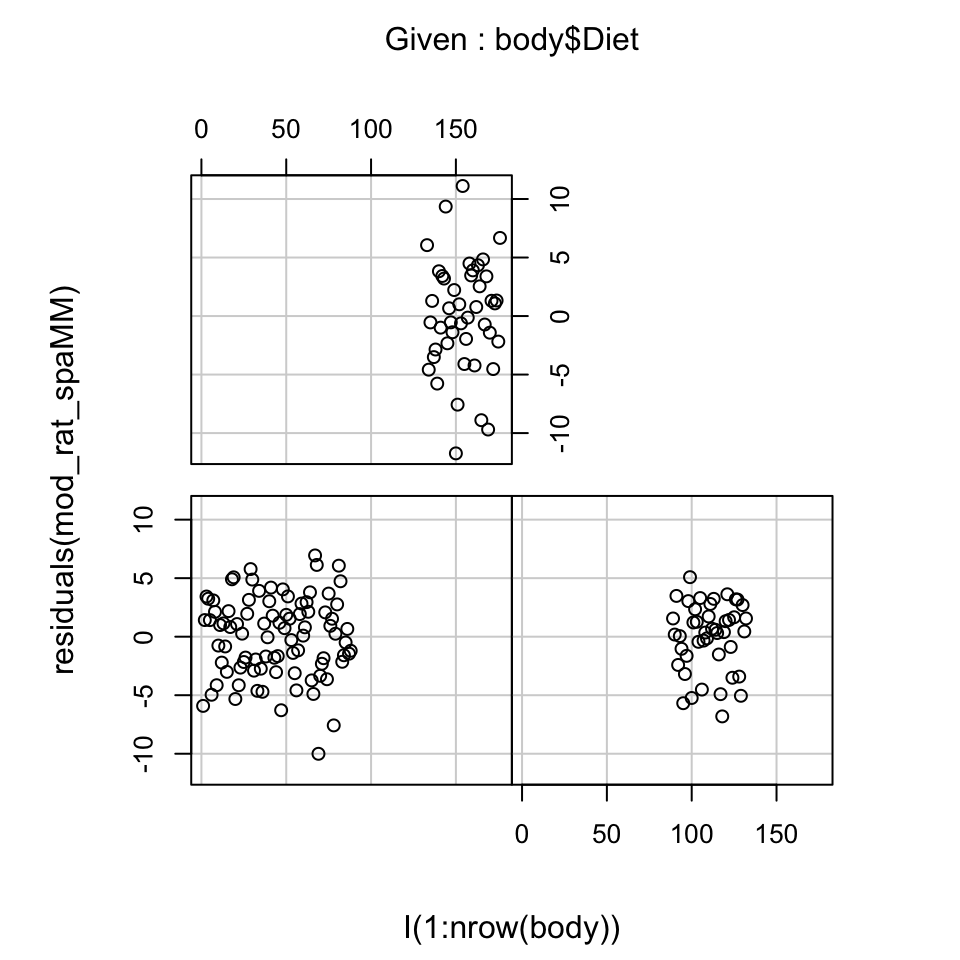

```r
coplot(residuals(mod_rat_spaMM) ~ I(1:nrow(body)) | body$Diet, show.given = FALSE)
```

## Let's revisit the rats

```r
mod_rat_hetero <- fitme(weight ~ Diet * Time + (Time|Rat) + AR1(1|Time), data = body,
                        method = "REML", resid.model = ~ Diet)
```

```r
summary.tables <- summary(mod_rat_hetero)
```

```r
summary.tables$phi_table
```

```
##               Estimate  Cond. SE
## (Intercept)  2.6702199 0.1698757
## Diet2       -0.3221747 0.2961120
## Diet3        0.6638038 0.2918609
```

```r
print(rbind(AIC(mod_rat_spaMM),
            AIC(mod_rat_hetero)))
```

```
##             marginal AIC:     conditional AIC:      dispersion AIC:        effective df:
## [1,]             1174.127             1035.876             1147.114             139.0042
## [2,]             1168.732             1027.644             1141.668             138.8131
```

## Let's re-test the overal effect of the diet

```r
mod_rat_hetero <- fitme(weight ~ Diet * Time + (Time|Rat) + AR1(1|Time), data = body,
                           method = "ML", resid.model = ~ Diet)

mod_rat_hetero0 <- fitme(weight ~ Time + (Time|Rat) + AR1(1|Time), data = body,
                           method = "ML", resid.model = ~ Diet)

anova(mod_rat_hetero, mod_rat_hetero0)
```

```
##      chi2_LR df      p_value
## p_v 47.73446  4 1.072063e-09
```

## Heteroscedasticity in LM

### Just do the same!

```r
set.seed(1L)
d <- data.frame(y = c(rnorm(100, mean = 10, sd = sqrt(10)),
                      rnorm(100, mean = 20, sd = sqrt(20))),
                group = factor(c(rep("A", 100), rep("B", 100))))

m <- fitme(y ~ group, resid.model = ~ group, data = d, method = "REML")
unique(m$phi)
```

```
## [1]  8.067621 18.350646
```

## What you need to remember

- how to handle temporal and spatial autocorrelation
- how to model heteroskedasticity

## Table of contents

## Mixed-effects models

- 4.0 Introduction to LMM
- 4.1 Random effects
- 4.2 Solving LM problems using LMM
- 4.3 A showcase of some useful applications
- 4.4 Introduction to GLMM
- 4.5 More complex mixed models